# LDPred2 exercise

John Shorter

2023-06-21

# Tutorial acknowedgement

This exercise is inspired from a tutorial by Florian Privé. https://privefl.github.io/bigsnpr/articles/LDpred2.html

Should we run out of time for this workshop, feel free to visit the tutorial by Florian, which includes a YouTube video.

# Installation

## Start with installing needed packages. This may take a few minutes.

If you do this before the workshop, it will save us some time!

```r
#install.packages("bigsnpr")
#install.packages("ggplot2")
#install.packages("dplyr")
```

## Let’s load the libraries

```r
library(bigsnpr)
```

```r
library(ggplot2)
library(dplyr)
```

# Which set of variants to use?

## To run LDpred2, you need

- GWAS summary statistics with marginal effect sizes, their standard errors, and the corresponding sample size(s),
- An LD (correlation) matrix computed from individuals of the same genetic ancestry as individuals used in the GWAS,
- individual-level data for tuning hyper-parameters (when using LDpred2-grid or lassosum2) and for testing the final models.

You need to restrict to genetic variants in common between all these datasets.

```r
## $pos is in build GRCh37 / hg19, but we provide positions in 2 other builds

info <- readRDS(runonce::download_file(
  "https://figshare.com/ndownloader/files/37802721",
  dir = "tmp-data", fname = "map_hm3_plus.rds"))
str(info)
```

```
## tibble [1,444,196 × 10] (S3: tbl_df/tbl/data.frame)
##  $ chr     : int [1:1444196] 1 1 1 1 1 1 1 1 1 1 ...
##  $ pos     : int [1:1444196] 68082 77866 87409 87647 88144 89654 565935 568631 720797 741397 ...
##  $ a0      : chr [1:1444196] "T" "C" "C" "T" ...
##  $ a1      : chr [1:1444196] "C" "T" "T" "C" ...
##  $ rsid    : chr [1:1444196] "rs367789441" "rs563593912" "rs139490478" "rs146836579" ...
##  $ af_UKBB : num [1:1444196] 0.0708 0.07691 0.07683 0.01353 0.00857 ...
##  $ ld      : num [1:1444196] 1.81 1.3 1.57 1.34 1.16 ...
##  $ block_id: int [1:1444196] 1 1 1 1 1 1 1 1 1 1 ...
##  $ pos_hg18: int [1:1444196] 57945 67729 77272 77510 78007 79517 555798 558494 710660 731260 ...
##  $ pos_hg38: int [1:1444196] 68082 77866 87409 87647 88144 89654 630555 633251 785417 806017 ...
```

# Downloading genotype data and summary statistics for the tutorial

This tutorial uses fake data for educational purposes only. Another tutorial using another dataset can be found at https://privefl.github.io/bigsnpr-extdoc/polygenic-scores-pgs.html.

You can download the tutorial data and unzip files in R. We store those files in a directory called “tmp-data” here

```r
# install.packages("runonce")
zip <- runonce::download_file(
  "https://github.com/privefl/bigsnpr/raw/master/data-raw/public-data3.zip",
  dir = "tmp-data")
unzip(zip)
```

First, you need to read genotype data from the PLINK files (or BGEN files) as well as the text file containing summary statistics.

```r
# Read from bed/bim/fam, it generates .bk and .rds files.
#snp_readBed("tmp-data/public-data3.bed")
```

```r
# Attach the "bigSNP" object in R session
obj.bigSNP <- snp_attach("tmp-data/public-data3.rds")
# See how the file looks like
str(obj.bigSNP, max.level = 2, strict.width = "cut")
```

```
## List of 3
##  $ genotypes:Reference class 'FBM.code256' [package "bigstatsr"] with 16 fields
##   ..and 26 methods, of which 12 are  possibly relevant:
##   ..  add_columns, as.FBM, bm, bm.desc, check_dimensions,
##   ..  check_write_permissions, copy#envRefClass, initialize, initialize#FBM,
##   ..  save, show#envRefClass, show#FBM
##  $ fam      :'data.frame':   503 obs. of  6 variables:
##   ..$ family.ID  : int [1:503] 0 0 0 0 0 0 0 0 0 0 ...
##   ..$ sample.ID  : chr [1:503] "HG00096" "HG00097" "HG00099" "HG00100" ...
##   ..$ paternal.ID: int [1:503] 0 0 0 0 0 0 0 0 0 0 ...
##   ..$ maternal.ID: int [1:503] 0 0 0 0 0 0 0 0 0 0 ...
##   ..$ sex        : int [1:503] 1 2 2 2 1 2 1 1 2 1 ...
##   ..$ affection  : num [1:503] -0.547 0.188 -0.407 -0.28 0.398 ...
##  $ map      :'data.frame':   45337 obs. of  6 variables:
##   ..$ chromosome  : int [1:45337] 1 1 1 1 1 1 1 1 1 1 ...
##   ..$ marker.ID   : chr [1:45337] "rs3934834" "rs12726255" "rs11260549" "rs37"..
##   ..$ genetic.dist: num [1:45337] 0.359 0.408 0.932 0.986 1.107 ...
##   ..$ physical.pos: int [1:45337] 1005806 1049950 1121794 1162435 1314015 1505..
##   ..$ allele1     : chr [1:45337] "T" "G" "A" "A" ...
##   ..$ allele2     : chr [1:45337] "C" "A" "G" "C" ...
##  - attr(*, "class")= chr "bigSNP"
```

```r
# Get aliases for useful slots
G   <- obj.bigSNP$genotypes
CHR <- obj.bigSNP$map$chromosome
POS <- obj.bigSNP$map$physical.pos
y   <- obj.bigSNP$fam$affection
(NCORES <- nb_cores())
```

```
## [1] 4
```

```r
sumstats <- bigreadr::fread2("tmp-data/public-data3-sumstats.txt")
str(sumstats)
```

```
## 'data.frame':    50000 obs. of  9 variables:
##  $ rsid   : chr  "rs3934834" "rs12726255" "rs11260549" "rs3766186" ...
##  $ chr    : int  1 1 1 1 1 1 1 1 1 1 ...
##  $ pos    : int  995669 1039813 1111657 1152298 1303878 1495118 1833906 2041373 2130121 2201709 ...
##  $ a0     : chr  "G" "T" "C" "C" ...
##  $ a1     : chr  "A" "C" "T" "A" ...
##  $ beta   : num  0.0125 0.027 0.0171 -0.0195 -0.0057 ...
##  $ beta_se: num  0.0157 0.0167 0.0179 0.0199 0.0213 ...
##  $ N      : int  15155 15155 15155 15155 15155 15155 15155 15155 15155 15155 ...
##  $ p      : num  0.426 0.107 0.342 0.328 0.789 ...
```

We split the individuals from the genotype data into “validation” (to choose best-performing hyper-parameters) and “test” (to evaluate final polygenic scores). Here we consider that there are 350 individuals to be used as validation set to tune hyper-parameters for LDpred2-grid and lassosum2. The other 153 individuals are used as test set to evaluate the final models.

```r
set.seed(1)
ind.val <- sample(nrow(G), 350)
ind.test <- setdiff(rows_along(G), ind.val)
```

# Matching variants between genotype data and summary statistics

To match variants contained in genotype data and summary statistics, the variables “chr” (chromosome number), “pos” (physical genetic position in bp), “a0” (reference allele) and “a1” (alternative allele) should be available in the summary statistics and in the genotype data. These 4 variables are used to match variants between the two data frames. From the summary statistics, you need to get “beta”, “beta_se” (standard errors), and “n_eff” (the effective sample sizes per variant for a GWAS using logistic regression, and simply the sample size for continuous traits).

```r
# sumstats$n_eff <- 4 / (1 / sumstats$n_case + 1 / sumstats$n_control)
# sumstats$n_case <- sumstats$n_control <- NULL
sumstats$n_eff <- sumstats$N
map <- setNames(obj.bigSNP$map[-3], c("chr", "rsid", "pos", "a1", "a0"))
#df_beta <- snp_match(sumstats, map)
```

Here, there is problem with the matching; this is due to having different genome builds. You can either convert between builds with snp_modifyBuild() (or directly use the converted positions in info), or match by rsIDs instead.

```r
df_beta <- snp_match(sumstats, map, join_by_pos = FALSE)  # use rsid instead of pos
```

```
## 50,000 variants to be matched.
```

```
## 0 ambiguous SNPs have been removed.
```

```
## 45,337 variants have been matched; 22,758 were flipped and 15,092 were reversed.
```

If no or few variants are actually flipped, you might want to disable the strand flipping option (strand_flip = FALSE) and maybe remove the few that were flipped (errors?)

# Quality control of GWAS summary statistics

# Computing LDpred2 scores genome-wide

Note that you should run LDpred2 genome-wide.

## Correlation

First, you need to compute correlations between variants. We recommend to use a window size of 3 cM (see the LDpred2 paper).

```r
# To convert physical positions (in bp) to genetic positions (in cM), use
# POS2 <- snp_asGeneticPos(CHR, POS, dir = "tmp-data", ncores = NCORES)
# To avoid downloading "large" files, `POS2` has been precomputed here
POS2 <- obj.bigSNP$map$genetic.dist
```

Let us create the on-disk sparse genome-wide correlation matrix on-the-fly:

```r
tmp <- tempfile(tmpdir = "tmp-data")

for (chr in 1:22) {

  # print(chr)

  ## indices in 'df_beta'
  ind.chr <- which(df_beta$chr == chr)
  ## indices in 'G'
  ind.chr2 <- df_beta$`_NUM_ID_`[ind.chr]

  corr0 <- snp_cor(G, ind.col = ind.chr2, size = 3 / 1000,
                   infos.pos = POS2[ind.chr2], ncores = NCORES)

  if (chr == 1) {
    ld <- Matrix::colSums(corr0^2)
    corr <- as_SFBM(corr0, tmp, compact = TRUE)
  } else {
    ld <- c(ld, Matrix::colSums(corr0^2))
    corr$add_columns(corr0, nrow(corr))
  }
}
```

To use the “compact” format for SFBMs, you need packageVersion(“bigsparser”) >= package_version(“0.5”). Make sure to reinstall {bigsnpr} after updating {bigsparser} to this new version (to avoid crashes).

```r
file.size(corr$sbk) / 1024^3  # file size in GB
```

```
## [1] 0.03205058
```

Note that you will need at least the same memory as this file size (to keep it cached for faster processing) + some other memory for all the results returned. If you do not have enough memory, processing will be very slow (because you would read the data from disk all the time). If using the one million HapMap3 variants, having 60 GB of memory should be enough.

# LDpred2-inf: infinitesimal model

```r
# Estimate of h2 from LD Score regression
(ldsc <- with(df_beta, snp_ldsc(ld, length(ld), chi2 = (beta / beta_se)^2,
                                sample_size = n_eff, blocks = NULL)))
```

```
##       int        h2
## 0.9496371 0.2981213
```

```r
h2_est <- ldsc[["h2"]]
```

```r
beta_inf <- snp_ldpred2_inf(corr, df_beta, h2 = h2_est)
```

```r
pred_inf <- big_prodVec(G, beta_inf, ind.row = ind.test, ind.col = df_beta[["_NUM_ID_"]])
pcor(pred_inf, y[ind.test], NULL)
```

```
## [1] 0.3171149 0.1668316 0.4529985
```

LDpred2-inf would very likely perform worse than the other models presented hereinafter. They actually recommend not to use it anymore!

# LDpred2(-grid): grid of models

In practice, we recommend to test multiple values for h2 and p.

```r
(h2_seq <- round(h2_est * c(0.3, 0.7, 1, 1.4), 4))
```

```
## [1] 0.0894 0.2087 0.2981 0.4174
```

```r
(p_seq <- signif(seq_log(1e-5, 1, length.out = 21), 2))
```

```
##  [1] 1.0e-05 1.8e-05 3.2e-05 5.6e-05 1.0e-04 1.8e-04 3.2e-04 5.6e-04 1.0e-03
## [10] 1.8e-03 3.2e-03 5.6e-03 1.0e-02 1.8e-02 3.2e-02 5.6e-02 1.0e-01 1.8e-01
## [19] 3.2e-01 5.6e-01 1.0e+00
```

```r
(params <- expand.grid(p = p_seq, h2 = h2_seq, sparse = c(FALSE, TRUE)))
```

```
##           p     h2 sparse
## 1   1.0e-05 0.0894  FALSE
## 2   1.8e-05 0.0894  FALSE
## 3   3.2e-05 0.0894  FALSE
## 4   5.6e-05 0.0894  FALSE
## 5   1.0e-04 0.0894  FALSE
## 6   1.8e-04 0.0894  FALSE
## 7   3.2e-04 0.0894  FALSE
## 8   5.6e-04 0.0894  FALSE
## 9   1.0e-03 0.0894  FALSE
## 10  1.8e-03 0.0894  FALSE
## 11  3.2e-03 0.0894  FALSE
## 12  5.6e-03 0.0894  FALSE
## 13  1.0e-02 0.0894  FALSE
## 14  1.8e-02 0.0894  FALSE
```

[output cut: 154 more lines]

```r
set.seed(1)  # to get the same result every time
# takes less than 2 min with 4 cores
beta_grid <- snp_ldpred2_grid(corr, df_beta, params, ncores = NCORES)
```

```r
pred_grid <- big_prodMat(G, beta_grid, ind.col = df_beta[["_NUM_ID_"]])
params$score <- apply(pred_grid[ind.val, ], 2, function(x) {
  if (all(is.na(x))) return(NA)
  summary(lm(y[ind.val] ~ x))$coef["x", 3]
  # summary(glm(y[ind.val] ~ x, family = "binomial"))$coef["x", 3]
})
```

Note that missing values represent models that diverged substantially.

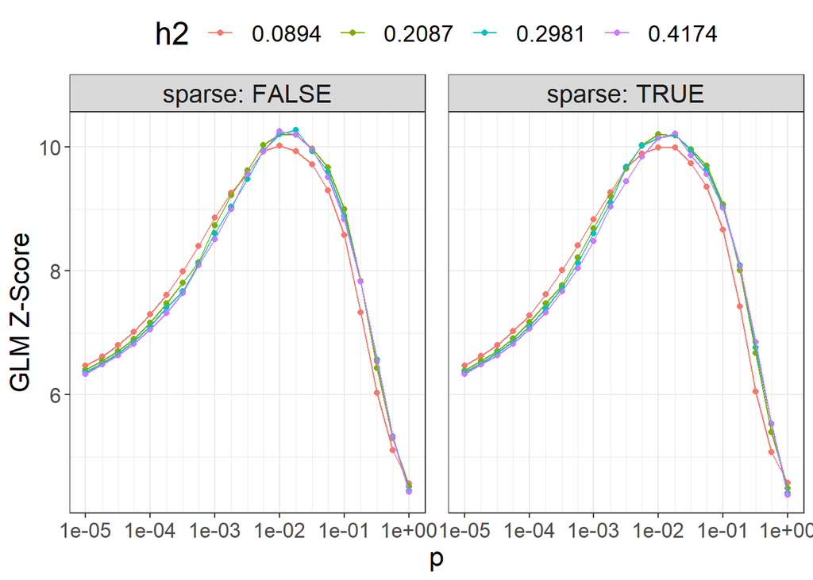

```r
ggplot(params, aes(x = p, y = score, color = as.factor(h2))) +
  theme_bigstatsr() +
  geom_point() +
  geom_line() +
  scale_x_log10(breaks = 10^(-5:0), minor_breaks = params$p) +
  facet_wrap(~ sparse, labeller = label_both) +
  labs(y = "GLM Z-Score", color = "h2") +
  theme(legend.position = "top", panel.spacing = unit(1, "lines"))
```

```r
params %>%
  mutate(sparsity = colMeans(beta_grid == 0), id = row_number()) %>%
  arrange(desc(score)) %>%
  mutate_at(c("score", "sparsity"), round, digits = 3) %>%
  slice(1:10)
```

```
##        p     h2 sparse  score sparsity  id
## 1  0.018 0.2981  FALSE 10.274    0.000  56
## 2  0.010 0.4174  FALSE 10.256    0.000  76
## 3  0.018 0.4174   TRUE 10.217    0.775 161
## 4  0.010 0.2981  FALSE 10.212    0.000  55
## 5  0.010 0.2087  FALSE 10.208    0.000  34
## 6  0.010 0.2087   TRUE 10.205    0.784 118
## 7  0.018 0.4174  FALSE 10.202    0.000  77
## 8  0.018 0.2981   TRUE 10.200    0.747 140
## 9  0.018 0.2087  FALSE 10.196    0.000  35
## 10 0.018 0.2087   TRUE 10.188    0.715 119
```

You can then choose the best model according to your preferred criterion (e.g. max AUC or r2).

Here, we use the Z-Score from the (linear or logistic) regression of the phenotype by the PRS since we have found it more robust than using the correlation or the AUC. It also enables adjusting for covariates in this step.

Also note that we separate both sparse and non-sparse models to show that their predictive performance are similar (in the original LDpred2 paper). In practice, if you do not really care about sparsity, you could choose the best LDpred2-grid model among all sparse and non-sparse models. If you do, choose the best sparse one (if it is close enough to the best one).

```r
best_beta_grid <- params %>%
  mutate(id = row_number()) %>%
  # filter(sparse) %>%
  arrange(desc(score)) %>%
  slice(1) %>%
  print() %>%
  pull(id) %>%
  beta_grid[, .]
```

```
##       p     h2 sparse    score id
## 1 0.018 0.2981  FALSE 10.27429 56
```

```r
pred <- big_prodVec(G, best_beta_grid, ind.row = ind.test,
                    ind.col = df_beta[["_NUM_ID_"]])
pcor(pred, y[ind.test], NULL)
```

```
## [1] 0.4978420 0.3682548 0.6084543
```

# LDpred2-auto: automatic model

Contrary to LDpred2-grid, LDpred2-auto does not need a validation set because it can directly infer values for hyper-parameters h2 and p. We recommend to run many chains in parallel with different initial values for p, which will be used for QC afterwards. In this paper, we have also introduced two new parameters in LDpred2-auto for improving its robustness, allow_jump_sign and shrink_corr, and recommend to use them

```r
coef_shrink <- 0.95  # reduce this up to 0.4 if you have some (large) mismatch with the LD ref

set.seed(1)  # to get the same result every time
# takes less than 2 min with 4 cores
multi_auto <- snp_ldpred2_auto(
  corr, df_beta, h2_init = h2_est,
  vec_p_init = seq_log(1e-4, 0.2, length.out = 30), ncores = NCORES,
  # use_MLE = FALSE,  # uncomment if you have convergence issues or when power is low (need v1.11.9)
  allow_jump_sign = FALSE, shrink_corr = coef_shrink)
str(multi_auto, max.level = 1)
```

```
## List of 30
##  $ :List of 12
##  $ :List of 12
##  $ :List of 12
##  $ :List of 12
##  $ :List of 12
##  $ :List of 12
##  $ :List of 12
##  $ :List of 12
##  $ :List of 12
##  $ :List of 12
##  $ :List of 12
##  $ :List of 12
##  $ :List of 12
##  $ :List of 12
```

[output cut: 16 more lines]

```r
str(multi_auto[[1]], max.level = 1)
```

```
## List of 12
##  $ beta_est      : num [1:45337] 5.92e-05 2.94e-04 9.30e-05 -1.10e-04 2.28e-05 ...
##  $ postp_est     : num [1:45337] 0.00564 0.01305 0.00661 0.00699 0.00503 ...
##  $ corr_est      : num [1:45337] 3.60e-05 1.87e-04 1.24e-05 -6.52e-05 -3.23e-05 ...
##  $ sample_beta   :Formal class 'dgCMatrix' [package "Matrix"] with 6 slots
##  $ path_p_est    : num [1:700] 0.000567 0.001407 0.001638 0.002563 0.003236 ...
##  $ path_h2_est   : num [1:700] 0.084 0.113 0.132 0.127 0.143 ...
##  $ path_alpha_est: num [1:700] 0.5 0.5 0.5 0.104 -0.328 ...
##  $ h2_est        : num 0.209
##  $ p_est         : num 0.011
##  $ alpha_est     : num -0.523
##  $ h2_init       : num 0.298
##  $ p_init        : num 1e-04
```

You can verify whether the chains “converged” by looking at the path of the chains:

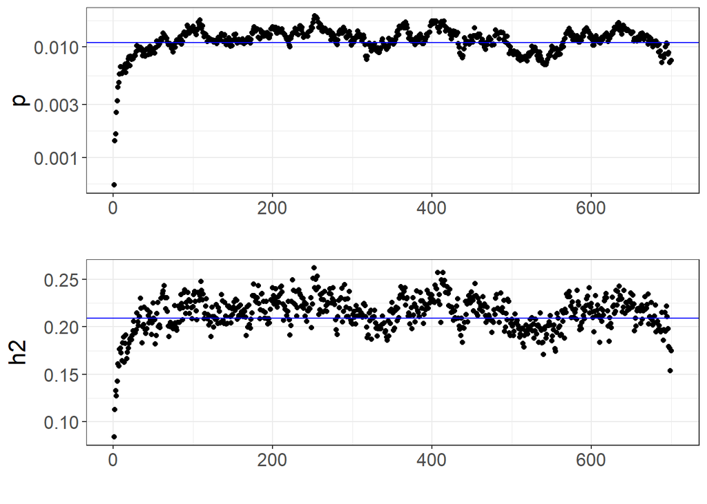

```r
auto <- multi_auto[[1]]  # first chain
plot_grid(
  qplot(y = auto$path_p_est) +
    theme_bigstatsr() +
    geom_hline(yintercept = auto$p_est, col = "blue") +
    scale_y_log10() +
    labs(y = "p"),
  qplot(y = auto$path_h2_est) +
    theme_bigstatsr() +
    geom_hline(yintercept = auto$h2_est, col = "blue") +
    labs(y = "h2"),
  ncol = 1, align = "hv"
)
```

In the LDpred2 paper, we proposed an automatic way of filtering bad chains by comparing the scale of the resulting predictions. We have tested a somewhat equivalent and simpler alternative since, which we recommend here:

```r
# `range` should be between 0 and 2
(range <- sapply(multi_auto, function(auto) diff(range(auto$corr_est))))
```

```
##  [1] 0.1210443 0.1216797 0.1209822 0.1197119 0.1187931 0.1199233 0.1202114
##  [8] 0.1195135 0.1214119 0.1206811 0.1189464 0.1204088 0.1196642 0.1195328
## [15] 0.1198751 0.1225441 0.1210127 0.1210234 0.1196245 0.1194824 0.1213715
## [22] 0.1188433 0.1203081 0.1196867 0.1210735 0.1201303 0.1209825 0.1195834
## [29] 0.1200190 0.1197259
```

```r
(keep <- which(range > (0.95 * quantile(range, 0.95, na.rm = TRUE))))
```

```
##  [1]  1  2  3  4  5  6  7  8  9 10 11 12 13 14 15 16 17 18 19 20 21 22 23 24 25
## [26] 26 27 28 29 30
```

To get the final effects / predictions, you should only use chains that pass this filtering:

```r
beta_auto <- rowMeans(sapply(multi_auto[keep], function(auto) auto$beta_est))
pred_auto <- big_prodVec(G, beta_auto, ind.row = ind.test, ind.col = df_beta[["_NUM_ID_"]])
```

```r
pcor(pred_auto, y[ind.test], NULL)
```

```
## [1] 0.4967147 0.3669594 0.6075102
```

# lassosum2: grid of models

lassosum2 is a re-implementation of the lassosum model that now uses the exact same input parameters as LDpred2 (corr and df_beta). It should be fast to run. It can be run next to LDpred2 and the best model can be chosen using the validation set. Note that parameter ‘s’ from lassosum has been replaced by a new parameter ‘delta’ in lassosum2, in order to better reflect that the lassosum model also uses L2-regularization (therefore, elastic-net regularization).

```r
beta_lassosum2 <- snp_lassosum2(corr, df_beta, ncores = NCORES)
```

```r
(params2 <- attr(beta_lassosum2, "grid_param"))
```

```
##           lambda delta num_iter time   sparsity
## 1   0.0611100278 0.001        2 0.01 0.99988971
## 2   0.0524138202 0.001        3 0.00 0.99971326
## 3   0.0449551186 0.001        4 0.00 0.99953680
## 4   0.0385578209 0.001        7 0.01 0.99925006
## 5   0.0330708848 0.001        8 0.02 0.99841189
## 6   0.0283647623 0.001       13 0.01 0.99711053
## 7   0.0243283403 0.001       19 0.02 0.99426517
## 8   0.0208663177 0.001       21 0.03 0.98645698
## 9   0.0178969551 0.001       51 0.08 0.96909809
## 10  0.0153501450 0.001       55 0.12 0.93951960
## 11  0.0131657564 0.001      134 0.28 0.89906699
## 12  0.0112922153 0.001      190 0.32 0.84668152
## 13  0.0096852867 0.001      232 0.53 0.78847299
## 14  0.0083070307 0.001      270 0.69 0.72536780
```

[output cut: 106 more lines]

```r
pred_grid2 <- big_prodMat(G, beta_lassosum2, ind.col = df_beta[["_NUM_ID_"]])
params2$score <- apply(pred_grid2[ind.val, ], 2, function(x) {
  if (all(is.na(x))) return(NA)
  summary(lm(y[ind.val] ~ x))$coef["x", 3]
  # summary(glm(y[ind.val] ~ x, family = "binomial"))$coef["x", 3]
})
```

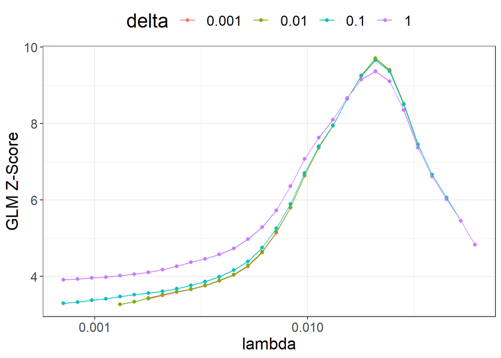

```r
ggplot(params2, aes(x = lambda, y = score, color = as.factor(delta))) +
  theme_bigstatsr() +
  geom_point() +
  geom_line() +
  scale_x_log10(breaks = 10^(-5:0)) +
  labs(y = "GLM Z-Score", color = "delta") +
  theme(legend.position = "top") +
  guides(colour = guide_legend(nrow = 1))
```

```r
best_grid_lassosum2 <- params2 %>%
  mutate(id = row_number()) %>%
  arrange(desc(score)) %>%
  print() %>%
  slice(1) %>%
  pull(id) %>%
  beta_lassosum2[, .]
```

```
##           lambda delta num_iter time   sparsity    score  id
## 1   0.0208663177 0.001       21 0.03 0.98645698 9.715332   8
## 2   0.0208663177 0.010       20 0.02 0.98647903 9.709724  38
## 3   0.0208663177 0.100       16 0.01 0.98623641 9.667190  68
## 4   0.0243283403 0.001       19 0.02 0.99426517 9.404453   7
## 5   0.0243283403 0.010       18 0.03 0.99424311 9.401482  37
## 6   0.0208663177 1.000        8 0.02 0.98544235 9.374476  98
## 7   0.0243283403 0.100       13 0.01 0.99415488 9.372091  67
## 8   0.0178969551 0.001       51 0.08 0.96909809 9.261133   9
## 9   0.0178969551 0.010       48 0.06 0.96903192 9.258114  39
## 10  0.0178969551 0.100       18 0.03 0.96872312 9.245390  69
## 11  0.0178969551 1.000        8 0.01 0.96726735 9.158597  99
## 12  0.0243283403 1.000        8 0.00 0.99351523 9.110868  97
## 13  0.0153501450 1.000        8 0.03 0.93574784 8.665074 100
## 14  0.0153501450 0.001       55 0.12 0.93951960 8.652003  10
```

[output cut: 106 more lines]

```r
# Choose the best among all LDpred2-grid and lassosum2 models
best_grid_overall <-
  `if`(max(params2$score, na.rm = TRUE) > max(params$score, na.rm = TRUE),
       best_grid_lassosum2, best_beta_grid)
```

# Inference with LDpred2-auto

LDpred2-auto has been very recently extended and improved to allow for estimating h2 , p , and α , a third parameter that controls how expected effect sizes relate to minor allele frequencies.

```r
# reduce this up to 0.4 if you have some (large) mismatch with the LD ref
# /!\ but the inference of h2 and p might be biased if you do this (see preprint)
coef_shrink <- 0.95

multi_auto <- snp_ldpred2_auto(
  corr, df_beta, h2_init = h2_est,
  vec_p_init = seq_log(1e-4, 0.2, length.out = 50), ncores = NCORES,
  burn_in = 500, num_iter = 500, report_step = 20,
  # use_MLE = FALSE,  # uncomment if you have convergence issues or when power is low (need v1.11.9)
  allow_jump_sign = FALSE, shrink_corr = coef_shrink)
```

```r
(range <- sapply(multi_auto, function(auto) diff(range(auto$corr_est))))
```

```
##  [1] 0.1203440 0.1201514 0.1201017 0.1199062 0.1200198 0.1217100 0.1192894
##  [8] 0.1206322 0.1194016 0.1205341 0.1209561 0.1209005 0.1202831 0.1203131
## [15] 0.1199622 0.1207713 0.1205029 0.1200927 0.1213750 0.1194640 0.1204270
## [22] 0.1200989 0.1205159 0.1199131 0.1200470 0.1212829 0.1207075 0.1203341
## [29] 0.1196193 0.1208523 0.1198907 0.1199829 0.1195500 0.1206379 0.1198903
## [36] 0.1197334 0.1204139 0.1202457 0.1213121 0.1206422 0.1203483 0.1208703
## [43] 0.1198859 0.1211088 0.1206820 0.1200267 0.1197001 0.1213215 0.1191943
## [50] 0.1213634
```

```r
(keep <- which(range > (0.95 * quantile(range, 0.95, na.rm = TRUE))))
```

```
##  [1]  1  2  3  4  5  6  7  8  9 10 11 12 13 14 15 16 17 18 19 20 21 22 23 24 25
## [26] 26 27 28 29 30 31 32 33 34 35 36 37 38 39 40 41 42 43 44 45 46 47 48 49 50
```

```r
all_h2 <- sapply(multi_auto[keep], function(auto) tail(auto$path_h2_est, 500))
quantile(all_h2, c(0.5, 0.025, 0.975))
```

```
##       50%      2.5%     97.5%
## 0.2178006 0.1894810 0.2483018
```

```r
all_p <- sapply(multi_auto[keep], function(auto) tail(auto$path_p_est, 500))
quantile(all_p, c(0.5, 0.025, 0.975))
```

```
##         50%        2.5%       97.5%
## 0.012294107 0.008627975 0.017112622
```

```r
all_alpha <- sapply(multi_auto[keep], function(auto) tail(auto$path_alpha_est, 500))
quantile(all_alpha, c(0.5, 0.025, 0.975))
```

```
##        50%       2.5%      97.5%
## -0.4925350 -0.9062350 -0.0419629
```

Predictive performance r2 can also be inferred from the Gibbs sampler: (In statistics, Gibbs sampling or a Gibbs sampler is a Markov chain Monte Carlo (MCMC) algorithm for obtaining a sequence of observations which are approximated from a specified multivariate probability distribution, when direct sampling is difficult.)

```r
bsamp <- lapply(multi_auto[keep], function(auto) auto$sample_beta)
all_r2 <- do.call("cbind", lapply(seq_along(bsamp), function(ic) {
  b1 <- bsamp[[ic]]
  Rb1 <- apply(b1, 2, function(x)
    coef_shrink * bigsparser::sp_prodVec(corr, x) + (1 - coef_shrink) * x)
  b2 <- do.call("cbind", bsamp[-ic])
  b2Rb1 <- as.matrix(Matrix::crossprod(b2, Rb1))
}))
quantile(all_r2, c(0.5, 0.025, 0.975))
```

```
##       50%      2.5%     97.5%
## 0.1150057 0.1044237 0.1264264
```

and compared to

```r
beta_auto <- rowMeans(sapply(multi_auto[keep], function(auto) auto$beta_est))
pred_auto <- big_prodVec(G, beta_auto, ind.col = df_beta[["_NUM_ID_"]])
pcor(pred_auto, y, NULL)^2
```

```
## [1] 0.2377858 0.1747458 0.3042043
```

These are not exactly the same, which we attribute to the small number of variants used in this tutorial data.

You can also get per-variant probabilities of being causal (for fine-mapping purposes)

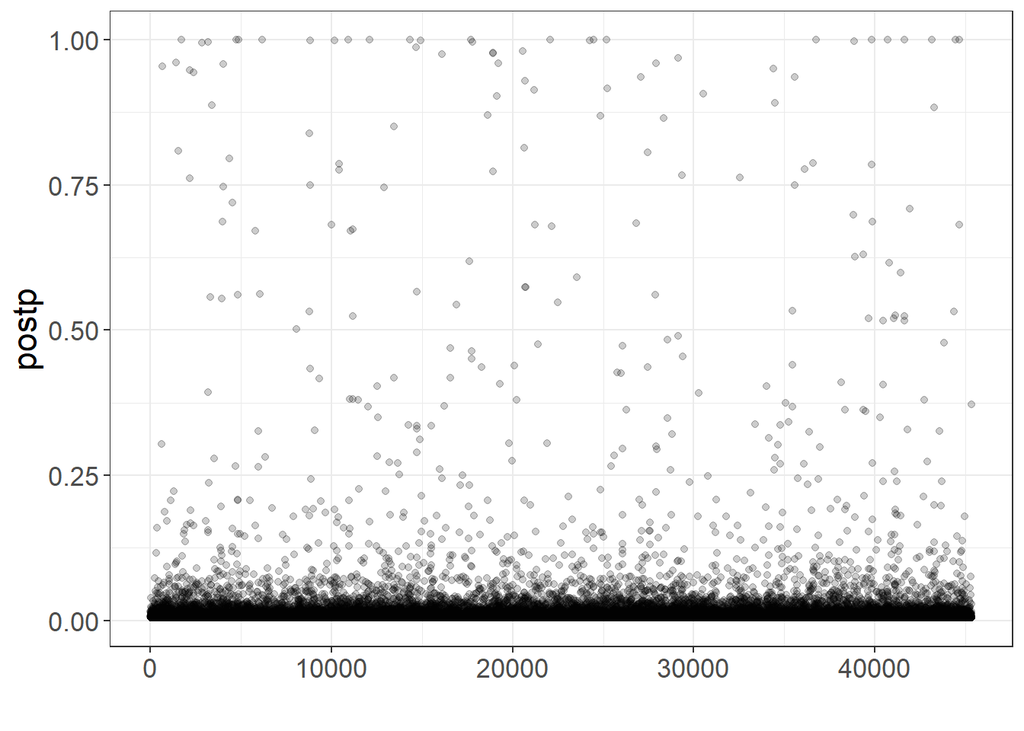

```r
postp <- rowMeans(sapply(multi_auto[keep], function(auto) auto$postp_est))
qplot(y = postp, alpha = I(0.2)) + theme_bigstatsr()
```

### References

Privé, F., Arbel, J., & Vilhjálmsson, B. J. (2020). LDpred2: better, faster, stronger. Bioinformatics, 36(22-23), 5424-5431.

Privé, F., Arbel, J., Aschard, H., & Vilhjálmsson, B. J. (2022). Identifying and correcting for misspecifications in GWAS summary statistics and polygenic scores. Human Genetics and Genomics Advances, 3(4), 100136.

Privé, F., Albiñana, C., Arbel, J., Pasaniuc, B., & Vilhjálmsson, B. J. (2022). Inferring disease architecture and predictive ability with LDpred2-auto. bioRxiv.